# CMPSCI 5390 - Semester Project - Task 1

The objective in this task is to design a convolutional neural network (not feed-forward neural network) to overfit your dataset.

This task uses the same model architecture as the Subtask 1, but without supplying the ground truth (output labels) as part of the model input.

Note: For the subtask in which ground truths are provided to the model during training, please see the file named `Task 1 output labels.ipynb`

# Imports and copy data

Import the various libraries used throughout the notebook and set the training and test data directories.

```python
import numpy as np, pathlib, matplotlib.pyplot as plt, tensorflow as tf
from tensorflow.keras import layers
from keras.callbacks import EarlyStopping

data_dir = pathlib.Path('/home/josh/data/asl/train')
test_data_dir = pathlib.Path('/home/josh/data/asl/test/')

image_count = len(list(data_dir.glob('*/*.jpg')))
print(image_count)

image_count = len(list(test_data_dir.glob('*/*.jpg')))
print(image_count)
```

```
2023-04-10 22:37:26.768137: I tensorflow/core/platform/cpu_feature_guard.cc:182] This TensorFlow binary is optimized to use available CPU instructions in performance-critical operations.
To enable the following instructions: AVX2 FMA, in other operations, rebuild TensorFlow with the appropriate compiler flags.
2023-04-10 22:37:27.533339: W tensorflow/compiler/tf2tensorrt/utils/py_utils.cc:38] TF-TRT Warning: Could not find TensorRT
```

```
87000
29
```

# Check versions and devices

Output the TensorFlow and Numpy versions along with the number of CPU's and number of GPU's available. I do this as I am running the notebook inside of Ubuntu on WSL, not in the cloud. I've had issues with certain versions of TensoFlow and Numpy, particularly around data augmentation.

```python
print(f"TensorFlow version: ", tf.__version__)
print(f"Numpy version: ", np.__version__)

print(f"Available CPU(s): ", len(tf.config.list_physical_devices('CPU')))
print(f"Available GPU(s): ", len(tf.config.list_physical_devices('GPU')))
```

```
TensorFlow version:  2.12.0
Numpy version:  1.23.5
Available CPU(s):  1
Available GPU(s):  1
```

[output not shown]

# Load data into traning and validation sets

Create the datasets using the Keras `image_dataset_from_directory` utility. This utility is useful when the dataset is too large to fit into the GPU's memory. It will load one batch at a time into memory and has automatic caching mechanisms to improve performance. At the end we print the class names and the number of classes.

```python
batch_size = 48
img_height = 256
img_width = 256

train_ds = tf.keras.utils.image_dataset_from_directory(
  data_dir,
  validation_split=0.2,
  subset="training",
  seed=123,
  image_size=(img_height, img_width),
  batch_size=batch_size)

valid_ds = tf.keras.utils.image_dataset_from_directory(
  data_dir,
  validation_split=0.2,
  subset="validation",
  seed=123,
  image_size=(img_height, img_width),
  batch_size=batch_size)


class_names = train_ds.class_names
num_classes = len(class_names)
print(class_names)
print(num_classes)
```

```
Found 87000 files belonging to 29 classes.
Using 69600 files for training.
Found 87000 files belonging to 29 classes.
Using 17400 files for validation.
['A', 'B', 'C', 'D', 'E', 'F', 'G', 'H', 'I', 'J', 'K', 'L', 'M', 'N', 'O', 'P', 'Q', 'R', 'S', 'T', 'U', 'V', 'W', 'X', 'Y', 'Z', 'del', 'nothing', 'space']
29
```

# Test display images

This selects 9 images from the dataset and displays them along with their labels. This is for verification purposes only to ensure that the dataset is loading images as expected.

[output not shown]

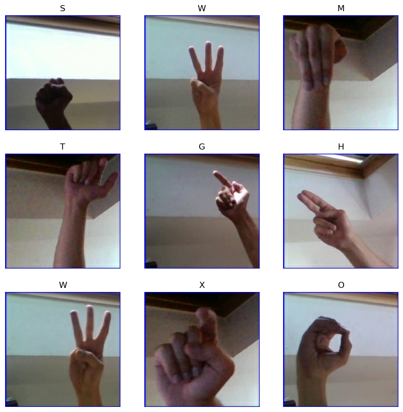

```python
plt.figure(figsize=(10, 10))
for images, labels in train_ds.take(1):
  for i in range(9):
    ax = plt.subplot(3, 3, i + 1)
    plt.imshow(images[i].numpy().astype("uint8"))
    plt.title(class_names[labels[i]])
    plt.axis("off")
```

# Create the model

This creates the model. This is the same architecture as Subtask 1.

```python
data_augmentation = tf.keras.Sequential(
  [
    layers.RandomFlip("horizontal",
                      input_shape=(img_height,
                                  img_width,
                                  3)),
    layers.RandomRotation(0.1),
    layers.RandomZoom(0.1),
    layers.RandomTranslation(width_factor=0.1,height_factor=0.1)
  ]
)

inputs = tf.keras.Input(shape=(256, 256, 3))
x = tf.keras.layers.Conv2D(filters=32, kernel_size=3, activation='relu')(inputs)
x = tf.keras.layers.MaxPooling2D((2, 2))(x)
x = tf.keras.layers.BatchNormalization()(x)

x = tf.keras.layers.Conv2D(filters=16, kernel_size=3, activation='relu')(x)
x = tf.keras.layers.MaxPooling2D((2, 2))(x)

x = tf.keras.layers.Conv2D(filters=16, kernel_size=3, activation='relu')(x)
x = tf.keras.layers.MaxPooling2D((2, 2))(x)

x = tf.keras.layers.Conv2D(filters=8, kernel_size=3, activation='relu')(x)
x = tf.keras.layers.MaxPooling2D((2, 2))(x)

x = tf.keras.layers.Conv2D(filters=4, kernel_size=3, activation='relu')(x)
x = tf.keras.layers.MaxPooling2D((2, 2))(x)

x = tf.keras.layers.Conv2D(filters=4, kernel_size=3, activation='relu')(x)
x = tf.keras.layers.MaxPooling2D((2, 2))(x)

x = tf.keras.layers.Flatten()(x)
x = tf.keras.layers.Dense(42, activation='relu')(x)
outputs = tf.keras.layers.Dense(num_classes, activation='softmax')(x)

model = tf.keras.Model(inputs=inputs, outputs=outputs)
```

# Create Callbacks

Here I create a custom callback function. This function monitors the training accuracy, when it reaches 100% it stops the training early.

```python
class MyThresholdCallback(tf.keras.callbacks.Callback):
    def __init__(self, threshold):
        super(MyThresholdCallback, self).__init__()
        self.threshold = threshold

    def on_epoch_end(self, epoch, logs=None):
        accuracy = logs["accuracy"]
        if accuracy >= self.threshold:
            self.model.stop_training = True

callback=MyThresholdCallback(threshold=1.0)
```

# Compile the Model

Here we set the optimizer and compile the model. We then print the sumamry of the model.

```python
optimizer = tf.keras.optimizers.Adam()
loss = tf.keras.losses.SparseCategoricalCrossentropy()

model.compile(optimizer=optimizer, loss=loss, metrics=['accuracy'])

model.summary()
```

[output not shown]

[output cut: 12 more lines]

```

 max_pooling2d_5 (MaxPooling  (None, 2, 2, 4)          0
 2D)

 flatten (Flatten)           (None, 16)                0

 dense (Dense)               (None, 42)                714

 dense_1 (Dense)             (None, 29)                1247

=================================================================
Total params: 11,529
Trainable params: 11,465
Non-trainable params: 64
_________________________________________________________________
```

# Display the model structure

Display a graphical representation of the model structure.

[figure not shown]

```python
tf.keras.utils.plot_model(model, show_layer_names=True, show_shapes=True)
```

# Train the model

Here we train the model. Note that here we are supplying the training data for both the training and validation sets to the `fit()` function.

```python
history = model.fit(train_ds, epochs=10, validation_data=train_ds, callbacks=[callback])
```

[output not shown]

# Investigate Learning

Plot the training and loss statistics for the training of the model.

[figure not shown]

[figure not shown]

```python
plt.plot(history.history['accuracy'], label='accuracy')
plt.plot(history.history['val_accuracy'], label = 'val_accuracy')
plt.xlabel('Epoch')
plt.ylabel('Accuracy')
plt.ylim([0, 1])
plt.legend(loc='lower right')

plt.figure()
plt.plot(history.history['loss']) # replace with accuracy/MAE
plt.plot(history.history['val_loss']) # replace with val_accuracy, etc.
plt.ylabel('loss')
plt.xlabel('epoch')
plt.legend(['training data', 'validation data'], loc='upper right')

plt.show()
```

# Validation Data Set

Evaluate the model.

```python
valid_loss, valid_acc = model.evaluate(valid_ds, verbose=2)
```

```
363/363 - 8s - loss: 0.0444 - accuracy: 0.9858 - 8s/epoch - 22ms/step
```

# Make Predictions and Evaluate the Model on Test Data

Plot all 29 images along with their ground truth labels(left side of colon) and predicted labels(right side of colon).

```
Found 29 files belonging to 29 classes.
```

[output not shown]

```
1/1 - 0s - loss: 0.3085 - accuracy: 0.9310 - 216ms/epoch - 216ms/step
```

[output not shown]

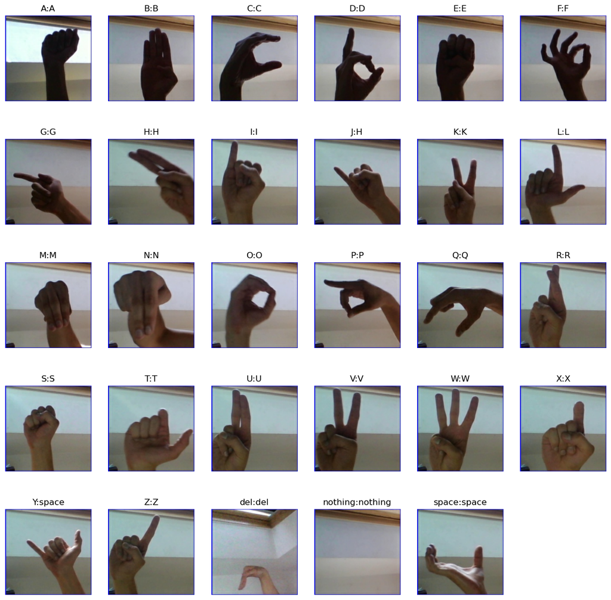

```python
test_ds = tf.keras.utils.image_dataset_from_directory(
  test_data_dir,
  validation_split=None,
  subset=None,
  seed=None,
  image_size=(img_height, img_width),
  batch_size=batch_size,
  shuffle=False
)

test_loss, test_acc = model.evaluate(test_ds, verbose=2)
test_class_names = test_ds.class_names
test_ds_instance = test_ds.take(1)

plt.figure(figsize=(15, 15))
for images, labels in test_ds_instance:
  for i in range(29):
    x = np.expand_dims(images[i], axis=0)
    p = model.predict(x, verbose=0)
    ax = plt.subplot(5, 6, i + 1)
    plt.imshow(images[i].numpy().astype("uint8"))
    plt.title(class_names[labels[i]] + ":" + class_names[p.argmax()])
    plt.axis("off")
```